# Question 4

Luisa Kalkert, Luke Richard, Nicholas Chandler

2025-07-22

# How do various statistics differ between males and females across the world?

```r
col_names_and_nas <- function(df) {
  for (i in seq_along(df)) {
    na_count <- sum(is.na(df[[i]]))
    empty_count <- sum(df[[i]] == "", na.rm = TRUE)
    cat(colnames(df)[i], ":", na_count + empty_count, "\n")
  }
}

# Read in data
full_df <- read.csv("../data/clean_data.csv", header = TRUE)

# Trim data
sub_cols <- grep("male|female", colnames(full_df),ignore.case=TRUE)
cols_to_keep <- colnames(full_df[, sub_cols])
cols_to_keep <- c(cols_to_keep, c("Geography..Map.references", "Geography..Geographic.coordinates", "Economy..Real.GDP.per.capita", "People.and.Society..Population...total", "People.and.Society..Birth.rate", "People.and.Society..Maternal.mortality.ratio", "People.and.Society..Infant.mortality.rate...total", "People.and.Society..Life.expectancy.at.birth...total.population", "People.and.Society..Population.growth.rate"))

trim_df <- full_df[-78,cols_to_keep]  # Note, we omit vatican city here due to lack of gender specific data
trim_df$Country <- full_df[-78,1]
rownames(trim_df) <- full_df[-78,1]

# Status report
col_names_and_nas(trim_df)
```

```
## People.and.Society..Population...male : 0
## People.and.Society..Population...female : 0
## People.and.Society..Median.age...male : 0
## People.and.Society..Median.age...female : 0
## People.and.Society..Infant.mortality.rate...male : 0
## People.and.Society..Infant.mortality.rate...female : 0
## People.and.Society..Life.expectancy.at.birth...male : 0
## People.and.Society..Life.expectancy.at.birth...female : 0
## People.and.Society..Tobacco.use...male : 39
## People.and.Society..Tobacco.use...female : 39
## People.and.Society..Literacy...male : 41
## People.and.Society..Literacy...female : 41
## People.and.Society..School.life.expectancy..primary.to.tertiary.education....male : 46
## People.and.Society..School.life.expectancy..primary.to.tertiary.education....female : 46
## Economy..Youth.unemployment.rate..ages.15.24....male : 11
## Economy..Youth.unemployment.rate..ages.15.24....female : 11
## Geography..Map.references : 0
## Geography..Geographic.coordinates : 0
## Economy..Real.GDP.per.capita : 2
## People.and.Society..Population...total : 0
## People.and.Society..Birth.rate : 0
## People.and.Society..Maternal.mortality.ratio : 19
## People.and.Society..Infant.mortality.rate...total : 0
## People.and.Society..Life.expectancy.at.birth...total.population : 0
## People.and.Society..Population.growth.rate : 0
## Country : 0
```

Clean the data

```r
# Economy..Real.GDP.per.capita
trim_df$Economy..Real.GDP.per.capita <- as.numeric(gsub("[$,]", "", str_extract(trim_df$Economy..Real.GDP.per.capita, "\\$[0-9,]+")))
colnames(trim_df)[colnames(trim_df) == "Economy..Real.GDP.per.capita"] <- "Real.GDP.per.capita.USD"

# People.and.Society..Population.growth.rate
trim_df$People.and.Society..Population.growth.rate <- as.numeric(sub("%", "", str_extract(trim_df$People.and.Society..Population.growth.rate, "[0-9.]+%"))) / 100
colnames(trim_df)[colnames(trim_df) == "People.and.Society..Population.growth.rate"] <- "Population.growth.rate.percent"

# People.and.Society..Birth.rate - births
trim_df$People.and.Society..Birth.rate <- as.numeric(str_extract(trim_df$People.and.Society..Birth.rate, "^[0-9]+")) / 1000
colnames(trim_df)[colnames(trim_df) == "People.and.Society..Birth.rate"] <- "Live.births.per.1000.people"

# People.and.Society..Population...total
trim_df$People.and.Society..Population...total <- as.numeric(gsub(",", "", str_extract(trim_df$People.and.Society..Population...total, "^[0-9,]+")))
colnames(trim_df)[colnames(trim_df) == "People.and.Society..Population...total"] <- "Total.population"

# People.and.Society..Maternal.mortality.ratio - deaths per live birth
trim_df$People.and.Society..Maternal.mortality.ratio <- as.numeric(gsub(",", "", str_extract(trim_df$People.and.Society..Maternal.mortality.ratio, "^[0-9]+"))) / 100000
colnames(trim_df)[colnames(trim_df) == "People.and.Society..Maternal.mortality.ratio"] <- "Maternal.deaths.per.100000.live.births"

# People.and.Society..Infant.mortality.rate...total - deaths per live birth
trim_df$People.and.Society..Infant.mortality.rate...total <- as.numeric(str_extract(trim_df$People.and.Society..Infant.mortality.rate...total, "^[0-9.]+")) / 1000
colnames(trim_df)[colnames(trim_df) == "People.and.Society..Infant.mortality.rate...total"] <- "Infant.deaths.per.1000.live.births"

# People.and.society..Life.expectancy.at.birth...total.population
trim_df$People.and.Society..Life.expectancy.at.birth...total.population <- as.numeric(str_extract(trim_df$People.and.Society..Life.expectancy.at.birth...total.population, "^[0-9.]+"))
colnames(trim_df)[colnames(trim_df) == "People.and.Society..Life.expectancy.at.birth...total.population"] <- "Life.expectancy.at.birth"

# Geography..Map.references
colnames(trim_df)[colnames(trim_df) == "Geography..Map.references"] <- "Continent"

# People.and.Society..Population...male
trim_df$People.and.Society..Population...male <- as.numeric(gsub(",", "", str_extract(trim_df$People.and.Society..Population...male, "^\\s*[0-9,]+")))
colnames(trim_df)[colnames(trim_df) == "People.and.Society..Population...male"] <- "Male.population"

# People.and.Society..Population...female
trim_df$People.and.Society..Population...female <- as.numeric(gsub(",", "", str_extract(trim_df$People.and.Society..Population...female, "^\\s*[0-9,]+")))
colnames(trim_df)[colnames(trim_df) == "People.and.Society..Population...female"] <- "Female.population"

# Economy..Youth.unemployment.rate..ages.15.24....female
trim_df$Economy..Youth.unemployment.rate..ages.15.24....female <- as.numeric(str_extract(trim_df$Economy..Youth.unemployment.rate..ages.15.24....female, "^\\s*[0-9.]+")) / 100
colnames(trim_df)[colnames(trim_df) == "Economy..Youth.unemployment.rate..ages.15.24....female"] <- "Female.unemployment.rate.15.24"

# Economy..Youth.unemployment.rate..ages.15.24....male
trim_df$Economy..Youth.unemployment.rate..ages.15.24....male <- as.numeric(str_extract(trim_df$Economy..Youth.unemployment.rate..ages.15.24....male, "^\\s*[0-9.]+")) / 100
colnames(trim_df)[colnames(trim_df) == "Economy..Youth.unemployment.rate..ages.15.24....male"] <- "Male.unemployment.rate.15.24"


# People.and.Society..School.life.expectancy..primary.to.tertiary.education....female
trim_df$People.and.Society..School.life.expectancy..primary.to.tertiary.education....female <- as.numeric(str_extract(trim_df$People.and.Society..School.life.expectancy..primary.to.tertiary.education....female, "^\\s*[0-9]+"))
colnames(trim_df)[colnames(trim_df) == "People.and.Society..School.life.expectancy..primary.to.tertiary.education....female"] <- "Female.expected.years.of.education"

# People.and.Society..School.life.expectancy..primary.to.tertiary.education....male
trim_df$People.and.Society..School.life.expectancy..primary.to.tertiary.education....male <- as.numeric(str_extract(trim_df$People.and.Society..School.life.expectancy..primary.to.tertiary.education....male, "^\\s*[0-9]+"))
colnames(trim_df)[colnames(trim_df) == "People.and.Society..School.life.expectancy..primary.to.tertiary.education....male"] <- "Male.expected.years.of.education"

# People.and.Society..Literacy...female
trim_df$People.and.Society..Literacy...female <- as.numeric(str_extract(trim_df$People.and.Society..Literacy...female, "^\\s*[0-9.]+")) / 100
colnames(trim_df)[colnames(trim_df) == "People.and.Society..Literacy...female"] <- "Female.literacy.rate"

# People.and.Society..Literacy...male
trim_df$People.and.Society..Literacy...male <- as.numeric(str_extract(trim_df$People.and.Society..Literacy...male, "^\\s*[0-9.]+")) / 100
colnames(trim_df)[colnames(trim_df) == "People.and.Society..Literacy...male"] <- "Male.literacy.rate"

# People.and.Society..Tobacco.use...female
trim_df$People.and.Society..Tobacco.use...female <- as.numeric(str_extract(trim_df$People.and.Society..Tobacco.use...female, "^\\s*[0-9.]+")) / 100
colnames(trim_df)[colnames(trim_df) == "People.and.Society..Tobacco.use...female"] <- "Female.proportion.of.tobacco.users"

# People.and.Society..Tobacco.use...male
trim_df$People.and.Society..Tobacco.use...male <- as.numeric(str_extract(trim_df$People.and.Society..Tobacco.use...male, "^\\s*[0-9.]+")) / 100
colnames(trim_df)[colnames(trim_df) == "People.and.Society..Tobacco.use...male"] <- "Male.proportion.of.tobacco.users"

# People.and.Society..Life.expectancy.at.birth...female
trim_df$People.and.Society..Life.expectancy.at.birth...female <- as.numeric(str_extract(trim_df$People.and.Society..Life.expectancy.at.birth...female, "^\\s*[0-9.]+"))
colnames(trim_df)[colnames(trim_df) == "People.and.Society..Life.expectancy.at.birth...female"] <- "Female.life.expectancy.at.birth"

# People.and.Society..Life.expectancy.at.birth...male
trim_df$People.and.Society..Life.expectancy.at.birth...male <- as.numeric(str_extract(trim_df$People.and.Society..Life.expectancy.at.birth...male, "^\\s*[0-9.]+"))
colnames(trim_df)[colnames(trim_df) == "People.and.Society..Life.expectancy.at.birth...male"] <- "Male.life.expectancy.at.birth"

# People.and.Society..Infant.mortality.rate...female
trim_df$People.and.Society..Infant.mortality.rate...female <- as.numeric( str_extract(trim_df$People.and.Society..Infant.mortality.rate...female, "^\\s*[0-9.]+")) / 1000
colnames(trim_df)[colnames(trim_df) == "People.and.Society..Infant.mortality.rate...female"] <- "Female.IMR.deaths.per.birth"

# People.and.Society..Infant.mortality.rate...male
trim_df$People.and.Society..Infant.mortality.rate...male <- as.numeric( str_extract(trim_df$People.and.Society..Infant.mortality.rate...male, "^\\s*[0-9.]+")) / 1000
colnames(trim_df)[colnames(trim_df) == "People.and.Society..Infant.mortality.rate...male"] <- "Male.IMR.deaths.per.birth"

# People.and.Society..Median.age...female
trim_df$People.and.Society..Median.age...female <- as.numeric( str_extract(trim_df$People.and.Society..Median.age...female, "^\\s*[0-9.]+"))
colnames(trim_df)[colnames(trim_df) == "People.and.Society..Median.age...female"] <- "Median.age.female"

# People.and.Society..Median.age...male
trim_df$People.and.Society..Median.age...male <- as.numeric( str_extract(trim_df$People.and.Society..Median.age...male, "^\\s*[0-9.]+"))
colnames(trim_df)[colnames(trim_df) == "People.and.Society..Median.age...male"] <- "Median.age.male"

head(trim_df, 10)
```

```
##             Male.population Female.population Median.age.male Median.age.female
## Afghanistan        20301066          19820486            20.0              20.1
## Albania             1531063           1576037            34.8              37.8
## Algeria            23854821          23167652            28.8              29.4
## Andorra               43652             41718            48.7              48.8
## Angola             18196058          19006003            15.8              16.8
## Anguilla               9107             10309            34.8              39.0
## Argentina          23274794          23719590            32.1              34.6
## Armenia             1456415           1520350            37.6              40.3
## Aruba                 59101             65962            39.3              42.4
## Australia          13305110          13463488            36.9              39.2
##             Male.IMR.deaths.per.birth Female.IMR.deaths.per.birth
## Afghanistan                    0.1097                      0.0925
## Albania                        0.0113                      0.0092
## Algeria                        0.0198                      0.0175
## Andorra                        0.0034                      0.0032
## Angola                         0.0607                      0.0503
## Anguilla                       0.0039                      0.0021
## Argentina                      0.0099                      0.0079
## Armenia                        0.0131                      0.0100
## Aruba                          0.0156                      0.0073
## Australia                      0.0032                      0.0027
##             Male.life.expectancy.at.birth Female.life.expectancy.at.birth
## Afghanistan                          52.8                            56.1
## Albania                              77.3                            82.8
## Algeria                              77.2                            78.7
## Andorra                              81.6                            86.2
## Angola                               60.8                            65.1
## Anguilla                             80.0                            85.3
## Argentina                            75.8                            82.0
## Armenia                              73.4                            80.1
## Aruba                                75.4                            81.6
## Australia                            81.3                            85.7
##             Male.proportion.of.tobacco.users Female.proportion.of.tobacco.users
## Afghanistan                            0.394                              0.072
## Albania                                0.388                              0.060
## Algeria                                0.413                              0.007
## Andorra                                0.353                              0.283
## Angola                                    NA                                 NA
## Anguilla                                  NA                                 NA
```

[output cut: 77 more lines]

```
## Argentina                               0.0090                     78.8
## Armenia                                 0.0116                     76.7
## Aruba                                   0.0115                     78.5
## Australia                               0.0029                     83.5
##             Population.growth.rate.percent     Country
## Afghanistan                         0.0222 Afghanistan
## Albania                             0.0016     Albania
## Algeria                             0.0154     Algeria
## Andorra                             0.0012     Andorra
## Angola                              0.0333      Angola
## Anguilla                            0.0174    Anguilla
## Argentina                           0.0079   Argentina
## Armenia                             0.0042     Armenia
## Aruba                               0.0108       Aruba
## Australia                           0.0113   Australia
```

# Paired “Univariate” Analysis

### Simple Male vs. Female KDE and Grouped Bar Charts

Also maps could be done, especially on the gap analysis ones and *juicy* topics e.g. life expectancy.

```r
colnames(trim_df)
```

```
##  [1] "Male.population"
##  [2] "Female.population"
##  [3] "Median.age.male"
##  [4] "Median.age.female"
##  [5] "Male.IMR.deaths.per.birth"
##  [6] "Female.IMR.deaths.per.birth"
##  [7] "Male.life.expectancy.at.birth"
##  [8] "Female.life.expectancy.at.birth"
##  [9] "Male.proportion.of.tobacco.users"
## [10] "Female.proportion.of.tobacco.users"
## [11] "Male.literacy.rate"
## [12] "Female.literacy.rate"
## [13] "Male.expected.years.of.education"
## [14] "Female.expected.years.of.education"
## [15] "Male.unemployment.rate.15.24"
## [16] "Female.unemployment.rate.15.24"
## [17] "Continent"
## [18] "Geography..Geographic.coordinates"
## [19] "Real.GDP.per.capita.USD"
## [20] "Total.population"
## [21] "Live.births.per.1000.people"
## [22] "Maternal.deaths.per.100000.live.births"
## [23] "Infant.deaths.per.1000.live.births"
## [24] "Life.expectancy.at.birth"
## [25] "Population.growth.rate.percent"
## [26] "Country"
```

### Population

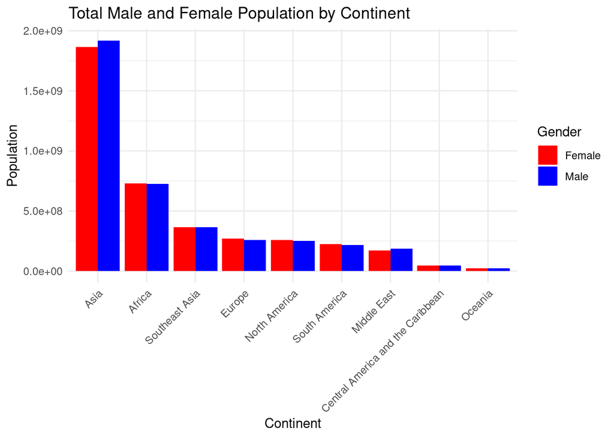

```r
agg_df<- aggregate(cbind(Male.population, Female.population) ~ Continent, data = trim_df, sum, na.rm=TRUE)

agg_df <- trim_df %>%
  group_by(Continent) %>%
  summarise(Male = sum(Male.population, na.rm=TRUE),
            Female = sum(Female.population, na.rm = TRUE)) %>%
  mutate(Total = Male + Female) %>%
  arrange(desc(Total)) %>%
  select(-Total) %>%
  pivot_longer(cols = c(Male, Female), names_to = "Gender", values_to = "Population")

ggplot(agg_df, aes(x = reorder(Continent, -Population, sum), y=Population, fill=Gender)) +
  geom_bar(stat="identity", position="dodge") +
  labs(title="Total Male and Female Population by Continent",
       x="Continent", y="Population") +
  theme_minimal() +
  theme(axis.text.x = element_text(angle=45, hjust=1)) +
  scale_fill_manual(values = c("Male" = "blue", "Female" = "red"))
```

KDE Function Definition

```r
plot_two_kde_plots_on_same_axes <- function(x1, x2,
                                            label1,
                                            label2,
                                            title,
                                            xlab,
                                            col1 = "blue",
                                            col2 = "red",
                                            lwd=2, legend.pos="topright", rug.alpha=0.4, ...) {
  x1 <- na.omit(x1)
  x2 <- na.omit(x2)

  xlim = range(c(x1,x2))

  plot(density(x1),
       xlab=xlab, main=title, xlim=xlim,
       col=col1, lwd=lwd, ...)
  lines(density(x2), col=col2, lwd=lwd)
  legend(legend.pos, legend=c(label1, label2), col=c(col1, col2), lwd=lwd)

  # Add a color coded rug
  rug(x1, col=adjustcolor(col1, alpha.f=rug.alpha), side=1)
  rug(x2, col=adjustcolor(col2, alpha.f=rug.alpha), side=1)
}
```

### Median Age Across Genders

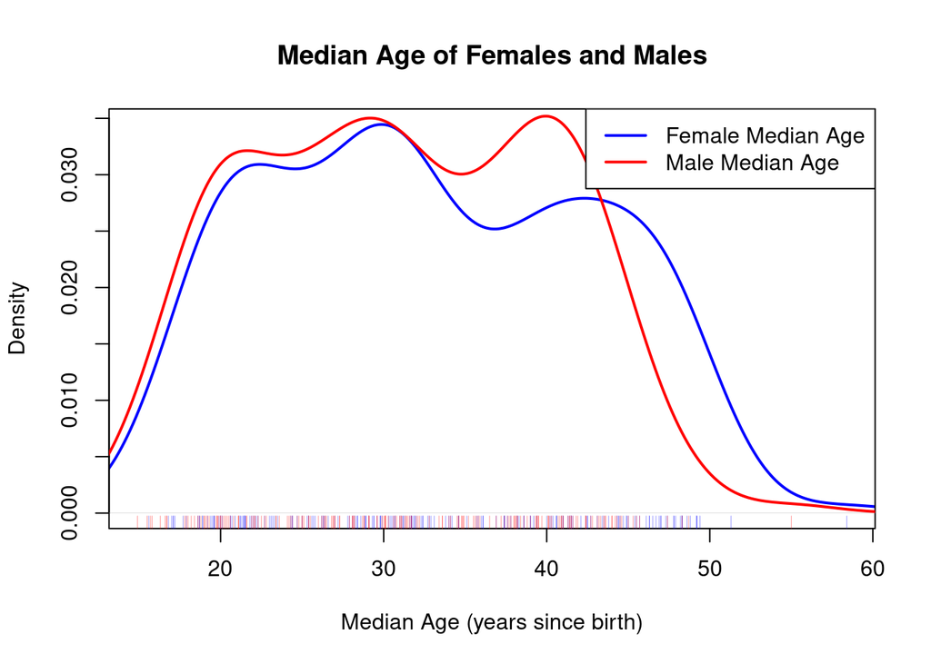

```r
plot_two_kde_plots_on_same_axes(trim_df$Median.age.female, trim_df$Median.age.male, "Female Median Age", "Male Median Age", "Median Age of Females and Males", "Median Age (years since birth)")
```

### Infant Mortality Ratio (deaths per birth)

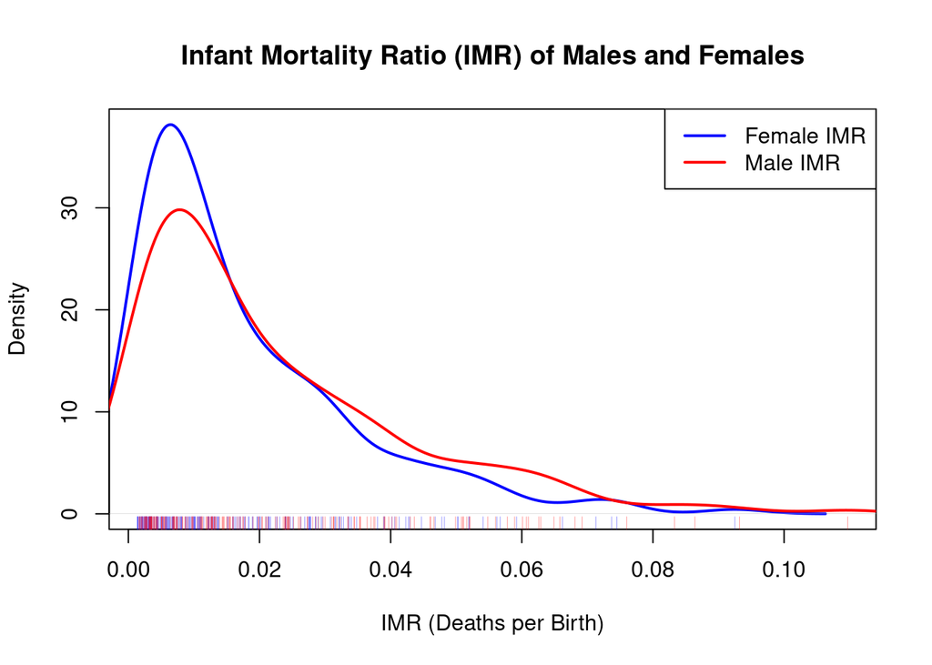

```r
plot_two_kde_plots_on_same_axes(trim_df$Female.IMR.deaths.per.birth, trim_df$Male.IMR.deaths.per.birth, "Female IMR", "Male IMR", "Infant Mortality Ratio (IMR) of Males and Females", "IMR (Deaths per Birth)")
```

### Life Expectancy

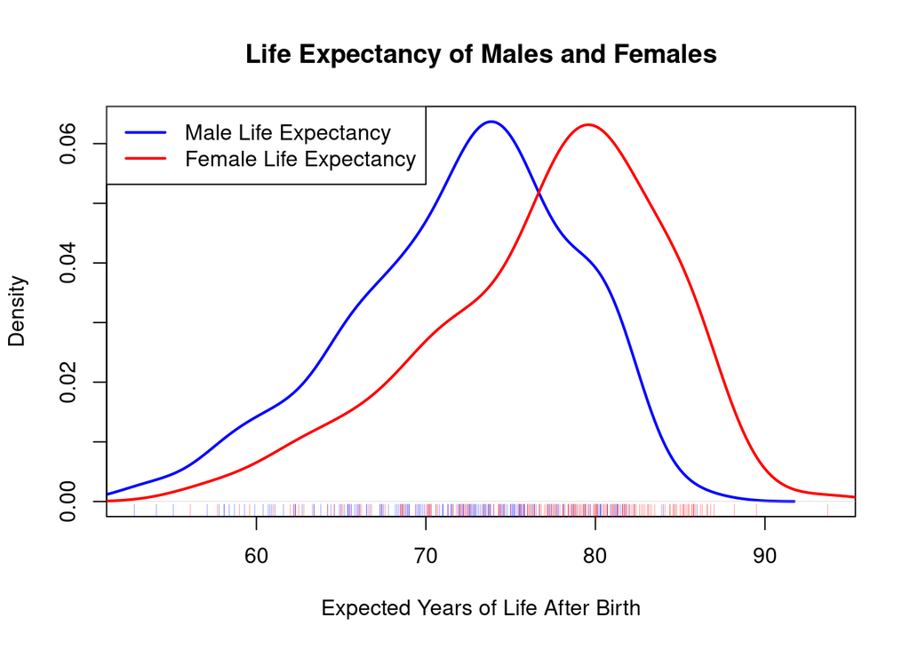

```r
plot_two_kde_plots_on_same_axes(trim_df$Male.life.expectancy.at.birth, trim_df$Female.life.expectancy.at.birth, "Male Life Expectancy", "Female Life Expectancy", "Life Expectancy of Males and Females", "Expected Years of Life After Birth", legend.pos="topleft")
```

### Proportion of population using tobacco

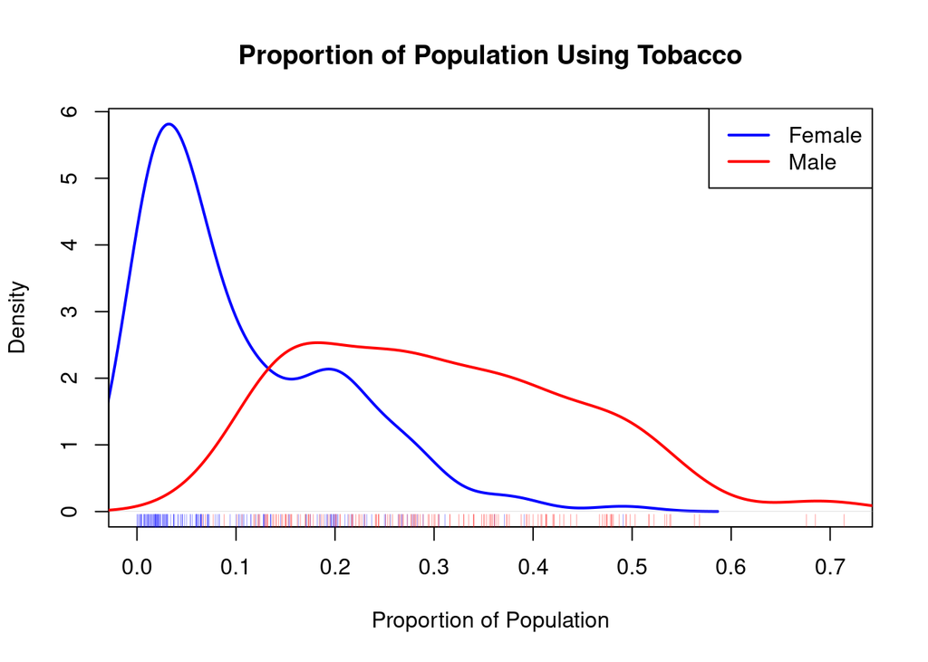

```r
plot_two_kde_plots_on_same_axes(trim_df$Female.proportion.of.tobacco.users, trim_df$Male.proportion.of.tobacco.users, "Female", "Male", "Proportion of Population Using Tobacco", "Proportion of Population")
```

### Literacy Rate

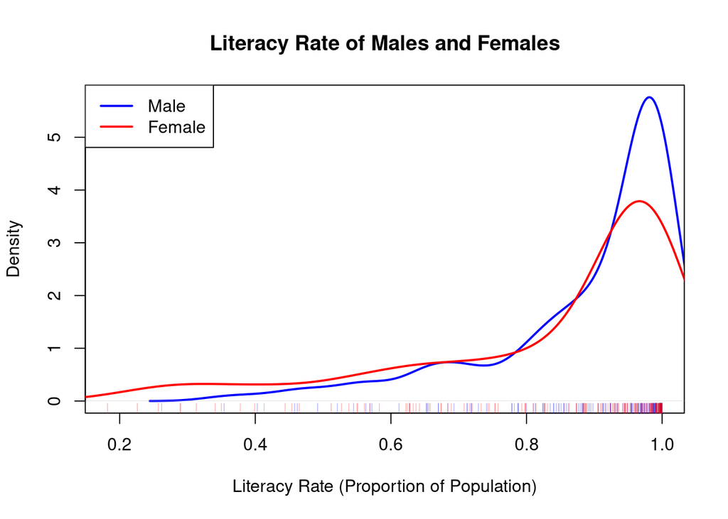

```r
plot_two_kde_plots_on_same_axes(trim_df$Male.literacy.rate, trim_df$Female.literacy.rate, "Male", "Female", "Literacy Rate of Males and Females", "Literacy Rate (Proportion of Population)", legend.pos="topleft")
```

### Expected Years of Education -

Should be a histogram? they are discrete but I want to show both distributions on one plot

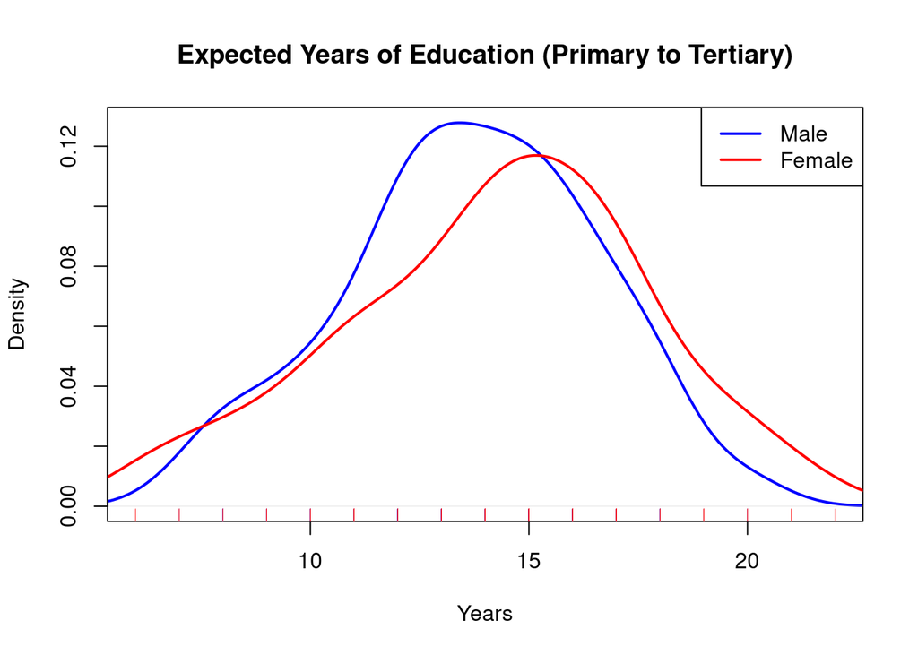

```r
plot_two_kde_plots_on_same_axes(trim_df$Male.expected.years.of.education, trim_df$Female.expected.years.of.education, "Male", "Female", "Expected Years of Education (Primary to Tertiary)", "Years")
```

### Unemployment Rate 15-24

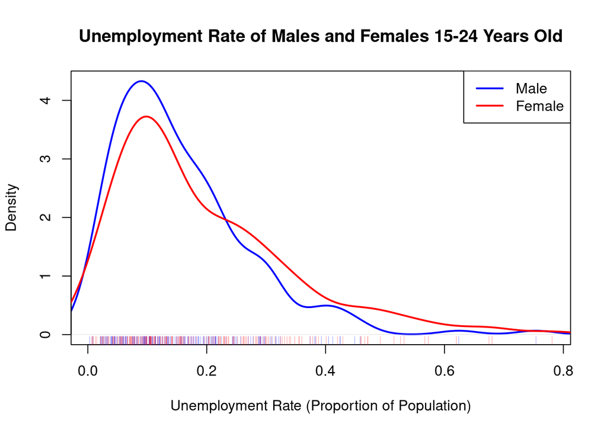

```r
plot_two_kde_plots_on_same_axes(trim_df$Male.unemployment.rate.15.24, trim_df$Female.unemployment.rate.15.24, "Male", "Female", "Unemployment Rate of Males and Females 15-24 Years Old", "Unemployment Rate (Proportion of Population)")
```

# Look at intra-country differences of selected variables

### Differences considered (Female - Male):

- Expected Years of Education
- Literacy Rate
- Life Expectancy

```r
trim_df$Diff.Expected.YOE <- trim_df$Female.expected.years.of.education - trim_df$Male.expected.years.of.education
trim_df$Diff.Literacy.Rate <- (trim_df$Female.literacy.rate - trim_df$Male.literacy.rate) * 100
trim_df$Diff.Life.Expectancy <- trim_df$Female.life.expectancy.at.birth - trim_df$Male.life.expectancy.at.birth

aggregate_by_continent <- function(df, continent_col = "Continent", ..., na.rm=TRUE) {
  value_cols <- quos(...)
  df %>%
    group_by(.data[[continent_col]]) %>%
    summarise(across(!!!value_cols, ~mean(.x, na.rm=na.rm), .names ="mean_{.col}")) %>%
    pivot_longer(cols=-all_of(continent_col), names_to="Variable", values_to="Values") %>%
    rename(Continent= all_of(continent_col))
}

agg_education_df <- aggregate_by_continent(trim_df, "Continent", "Diff.Expected.YOE")
agg_litrate_df <- aggregate_by_continent(trim_df, "Continent", "Diff.Literacy.Rate")
agg_life_expect_df <- aggregate_by_continent(trim_df, "Continent", "Diff.Life.Expectancy")
```

Plot the continent average bar charts:

```r
par(mfrow=c(1,3))
agg_education_df
```

```
## # A tibble: 9 × 3
##   Continent                         Variable                Values
##   <chr>                             <chr>                    <dbl>
## 1 Africa                            mean_Diff.Expected.YOE -0.189
## 2 Asia                              mean_Diff.Expected.YOE  0.0455
## 3 Central America and the Caribbean mean_Diff.Expected.YOE  1.19
## 4 Europe                            mean_Diff.Expected.YOE  0.897
## 5 Middle East                       mean_Diff.Expected.YOE  0.786
## 6 North America                     mean_Diff.Expected.YOE  0.75
## 7 Oceania                           mean_Diff.Expected.YOE  0.833
## 8 South America                     mean_Diff.Expected.YOE  1.38
## 9 Southeast Asia                    mean_Diff.Expected.YOE  0.444
```

```r
agg_litrate_df
```

```
## # A tibble: 9 × 3
##   Continent                         Variable                 Values
##   <chr>                             <chr>                     <dbl>
## 1 Africa                            mean_Diff.Literacy.Rate -11.2
## 2 Asia                              mean_Diff.Literacy.Rate  -5.39
## 3 Central America and the Caribbean mean_Diff.Literacy.Rate  -0.860
## 4 Europe                            mean_Diff.Literacy.Rate  -0.312
## 5 Middle East                       mean_Diff.Literacy.Rate  -5.14
## 6 North America                     mean_Diff.Literacy.Rate  -1.60
## 7 Oceania                           mean_Diff.Literacy.Rate  -0.629
## 8 South America                     mean_Diff.Literacy.Rate  -1.46
## 9 Southeast Asia                    mean_Diff.Literacy.Rate  -4.03
```

```r
agg_life_expect_df
```

```
## # A tibble: 9 × 3
##   Continent                         Variable                  Values
##   <chr>                             <chr>                      <dbl>
## 1 Africa                            mean_Diff.Life.Expectancy   4.02
## 2 Asia                              mean_Diff.Life.Expectancy   5.75
## 3 Central America and the Caribbean mean_Diff.Life.Expectancy   4.90
## 4 Europe                            mean_Diff.Life.Expectancy   5.90
## 5 Middle East                       mean_Diff.Life.Expectancy   3.81
## 6 North America                     mean_Diff.Life.Expectancy   5.37
## 7 Oceania                           mean_Diff.Life.Expectancy   4.92
## 8 South America                     mean_Diff.Life.Expectancy   6.45
## 9 Southeast Asia                    mean_Diff.Life.Expectancy   4.82
```

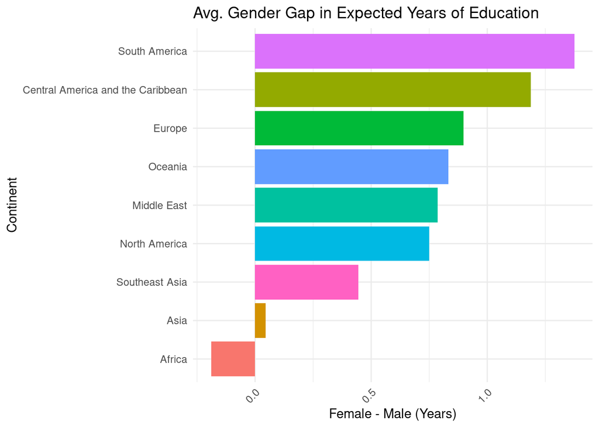

```r
plot_diff_by_continent <- function(df, title, ylab) {
  ggplot(df, aes(x = reorder(Continent, Values), y = Values, fill = Continent)) +
    geom_col(show.legend = FALSE) +
    labs(title = title, x = "Continent", y = ylab) +
    theme_minimal() +
    theme(axis.text.x = element_text(angle=45, hjust=1)) +
    coord_flip()
}

plot_diff_by_continent(agg_education_df,
                       title="Avg. Gender Gap in Expected Years of Education",
                       ylab="Female - Male (Years)")
```

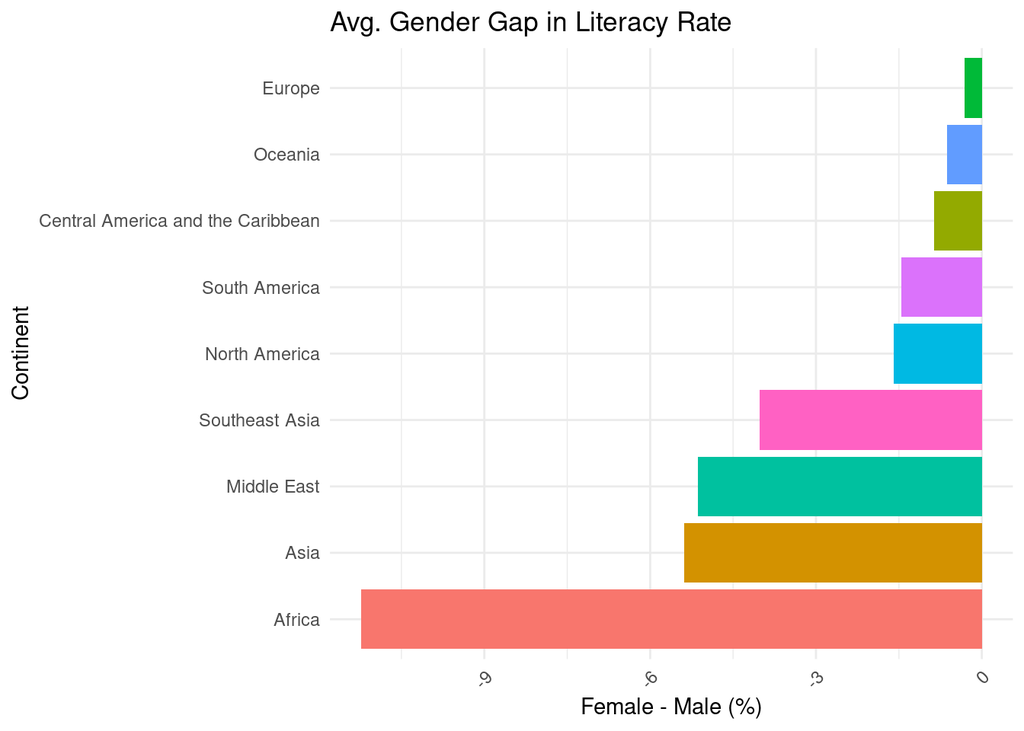

```r
plot_diff_by_continent(agg_litrate_df,
                       title="Avg. Gender Gap in Literacy Rate",
                       ylab = "Female - Male (%)")
```

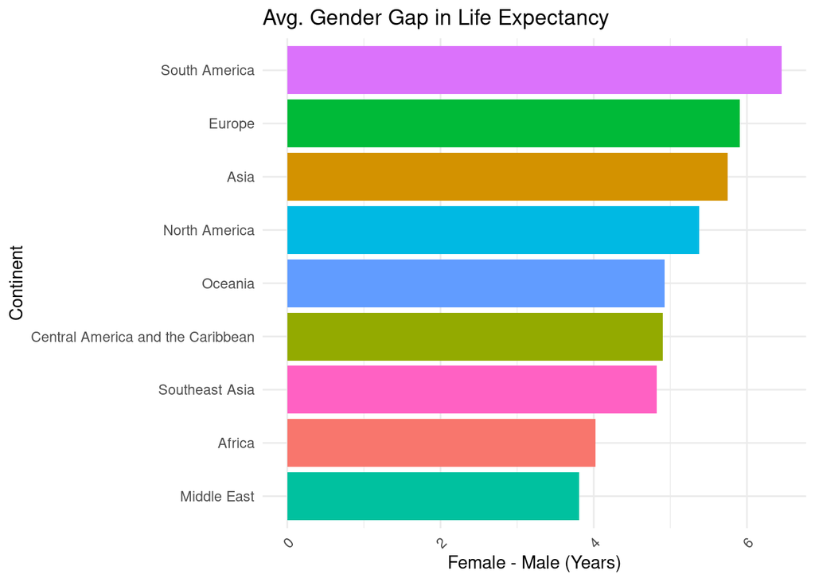

```r
plot_diff_by_continent(agg_life_expect_df,
                       title = "Avg. Gender Gap in Life Expectancy",
                       ylab = "Female - Male (Years)")
```

# Multivariate Analysis

## PCA on gendered cols

```r
gendered_df <- trim_df[,c("Male.population", "Female.population", "Median.age.male", "Median.age.female", "Male.IMR.deaths.per.birth", "Female.IMR.deaths.per.birth", "Male.life.expectancy.at.birth", "Female.life.expectancy.at.birth")]

pca_result <- prcomp(na.omit(gendered_df), center = TRUE, scale. = TRUE)

summary(pca_result)
```

```
## Importance of components:
##                           PC1    PC2     PC3     PC4     PC5     PC6     PC7
## Standard deviation     2.2975 1.4147 0.69101 0.44967 0.15816 0.10000 0.07221
## Proportion of Variance 0.6598 0.2502 0.05969 0.02528 0.00313 0.00125 0.00065
## Cumulative Proportion  0.6598 0.9100 0.96965 0.99493 0.99806 0.99931 0.99996
##                            PC8
## Standard deviation     0.01834
## Proportion of Variance 0.00004
## Cumulative Proportion  1.00000
```

```r
raw_variance <- pca_result$sdev^2

pve <- raw_variance / sum(raw_variance)

cumulative_pve = cumsum(pve)

pca_performance_data <- data.frame(
  PC = factor(1:length(pve), levels = 1:length(pve)),
  RawVariance = raw_variance,
  PVE = pve,
  CumulativePVE = cumulative_pve
)
```

PC Variances Plot:

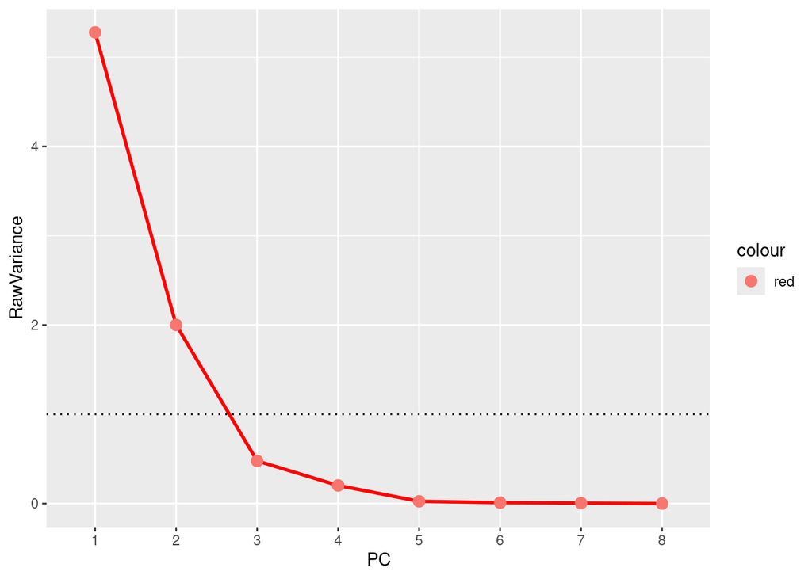

```r
ggplot(pca_performance_data, aes(x=PC, y=RawVariance)) +
  geom_line(aes(group=1), color="red", size=1) +
  geom_point(aes(color="red"), size=3)+
  geom_hline(yintercept=1, linetype="dotted", color="black")
```

```r
  labs(
    title = "Raw Variance",
    x = "Principal Components",
    y = "Raw Variance"
  ) +
  theme_minimal() +
  theme(axis.text.x = element_text(angle = 45, hjust=1), legend.position="none")
```

The first two principal components aggregate *information*, in the sense that if we view variance as information and values larger than one an aggregation of information (since all variables were standardized), the first two principal components have variance larger than one.

Cumulative Proportion of Variance Explained (CPVE) plot:

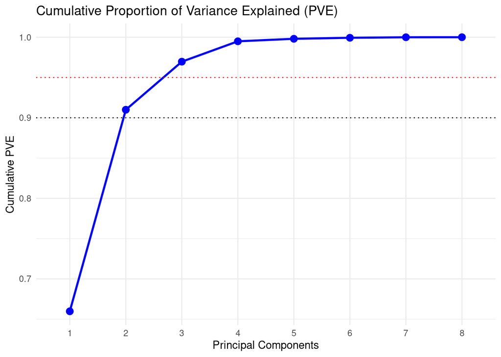

```r
ggplot(pca_performance_data, aes(x = PC, y = CumulativePVE, group=1)) +
  geom_line(color="blue", size=1) +
  geom_point(color="blue", size=3) +
  geom_hline(yintercept=0.9, linetype="dotted", color="black") +
  geom_hline(yintercept=0.95, linetype="dotted", color="red") +
  labs(
    title = "Cumulative Proportion of Variance Explained (PVE)",
    x = "Principal Components",
    y = "Cumulative PVE"
  ) +
  theme_minimal()
```

To capture 90% of the variance, two principal components are needed.

To capture 95% percent of the variance, three principal components are needed.

Here we plot the loading vectors of the PCA on the axes of the first and second principal components.

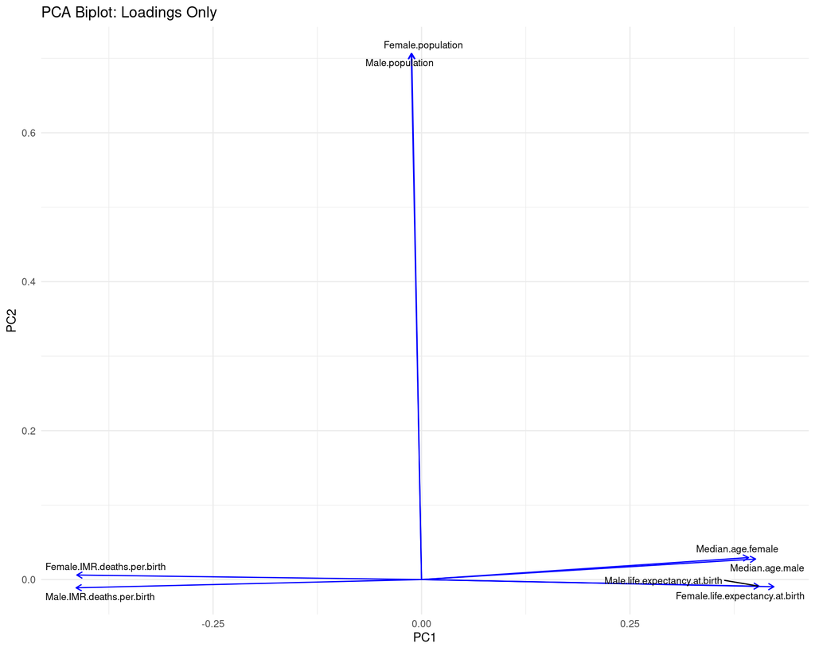

```r
# Create dataframe for loadings
loadings_df <- as.data.frame(pca_result$rotation[, 1:2])
loadings_df$varname <- rownames(loadings_df)

ggplot(loadings_df, aes(x = PC1, y = PC2)) +
  geom_segment(aes(x = 0, y = 0, xend = PC1, yend = PC2),
               arrow = arrow(length = unit(0.2,"cm")), color = "blue") +
  geom_text_repel(aes(label = varname), size = 3, max.overlaps = 100) +
  labs(title = "PCA Biplot: Loadings Only") +
  theme_minimal()
```

From the PCA we can see that, perhaps obviously, most of the variance is contained in the variable types rather than the gender. While each country may have differing values for both males and females, the measurement taken has more of an effect than the subsetting of the population measured. Still, we do see slight differences, most notably in the infant mortality rates between males and females.

To interpret the Biplot in the classical manner:

- PC1 appears to contain information about length of life, summarizing the metrics: life expectancy, median age, and infant mortality rate. Larger values of PC1 appear to occur in countries with less death of children and longer life spans.
- PC2 appears to contain population information, with large values indicating larger populations.
- There appears to be a contrast between male/female life expectancy and female IMR along PC1.

Note the similarity to the PCA in question 1, there appears to be a trend of “richness” and “size”.

Here we plot the most *extreme* observations defined:
$$\text{extreme_score}_i = \sqrt{\text{PC}1_i^2 +
\text{PC}2_i^2}$$

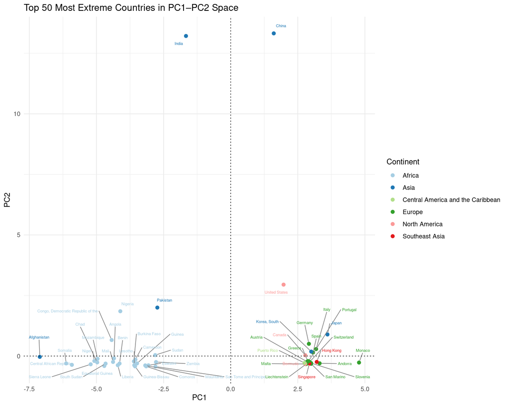

```r
meta_df <- trim_df[, c("Country", "Continent")]
# Get PCA scores (observations)
scores_df <- as.data.frame(pca_result$x[, 1:2])
scores_df$Country <- rownames(scores_df)

# Add distance from origin in PC1-PC2 space
scores_df <- scores_df %>%
  mutate(Distance = sqrt(PC1^2 + PC2^2))

# Keep top 10 extreme countries - euclidean norm of first two principal components
top_extremes <- scores_df %>%
  arrange(desc(Distance)) %>%
  slice_head(n = 50)


top_extremes <- top_extremes %>%
  left_join(meta_df, by = "Country")

# Plot
ggplot(top_extremes, aes(x = PC1, y = PC2, label = Country, color = Continent)) +
  geom_point(size = 2) +
  geom_text_repel(
    size = 2,
    max.overlaps = Inf,        # allow all to be plotted
    force = 2,                 # increase repulsion strength
    force_pull = 0.1,          # balance between point and label
    box.padding = 0.5,         # more space around text
    point.padding = 0.3,       # space between text and point
    segment.color = "grey50",  # optional connector color
    segment.size = 0.4
  ) +
  geom_hline(yintercept=0, linetype="dotted", color="black") +
  geom_vline(xintercept=0, linetype="dotted", color="black") +
  labs(title = "Top 50 Most Extreme Countries in PC1–PC2 Space",
       x = "PC1", y = "PC2") +
  theme_minimal() +
  scale_color_brewer(palette = "Paired")
```

KDE on principal components

```r
# Get scores
pc_scores <- as.data.frame(pca_result$x[, 1:2])
colnames(pc_scores) <- c("PC1", "PC2")
pc_scores$Country <- scores_df$Country

# Define a symmetric range around (0,0)
max_abs <- max(abs(pc_scores$PC1), abs(pc_scores$PC2))
grid_limit <- ceiling(max_abs) + 1  # Pad

# 2D KDE
kde <- kde2d(pc_scores$PC1, pc_scores$PC2,
             n=100, lims= c(-grid_limit, grid_limit, -grid_limit, grid_limit))


p <- plot_ly() %>%
  add_surface(
    x = ~kde$x,
    y = ~kde$y,
    z = ~t(kde$z),  # kde2d and plotly disagree here, transpose it!
    showscale = FALSE,
    showlegend=FALSE,
    opacity = 0.8
  ) %>%

  add_markers(
    data = pc_scores,
    x = ~PC1,
    y = ~PC2,
    z = rep(min(kde$z), nrow(pc_scores)) - 0.002, #slight offset below the surface
    text = ~paste("Country: ", Country, "<br>PC1:", round(PC1, 2), "<br>PC2:", round(PC2, 2)),
    hoverinfo = "text",
    marker = list(color = 'cyan', size = 4),
    type = "scatter3d",
    mode = "markers"
  ) %>%

  layout(
    title = "Interactive 3D KDE of PC1-PC2",
    scene = list(
      xaxis = list(title = "PC1 (x)", range = c(-grid_limit, grid_limit)),
      yaxis = list(title = "PC2 (y)", range = c(-grid_limit, grid_limit)),
      zaxis = list(title = "Density")
    )
  )

p
```

[interactive chart not shown]

In the KDE plot, one can observe that none of the scores are very negative along PC2. This is likely due to the fact that PC2 is made up of population primarily, population is exponentially distributed, and none of the countries have negative population. Thus the scores tend towards larger values of PC2.

## Pairs plots

```r
par(mar = c(8,8,3,3))  # Modify margins to make the plot larger (top, left, bottom, right)
colnames(gendered_df)
```

```
## [1] "Male.population"                 "Female.population"
## [3] "Median.age.male"                 "Median.age.female"
## [5] "Male.IMR.deaths.per.birth"       "Female.IMR.deaths.per.birth"
## [7] "Male.life.expectancy.at.birth"   "Female.life.expectancy.at.birth"
```

```r
colnames(gendered_df) <- c("Male.population", "Female.population", "Male.median.age", "Female.median.age", "Male IMR", "Female IMR", "M.Life.Expectancy", "F.Life.Expectancy")
colnames(gendered_df)
```

```
## [1] "Male.population"   "Female.population" "Male.median.age"
## [4] "Female.median.age" "Male IMR"          "Female IMR"
## [7] "M.Life.Expectancy" "F.Life.Expectancy"
```

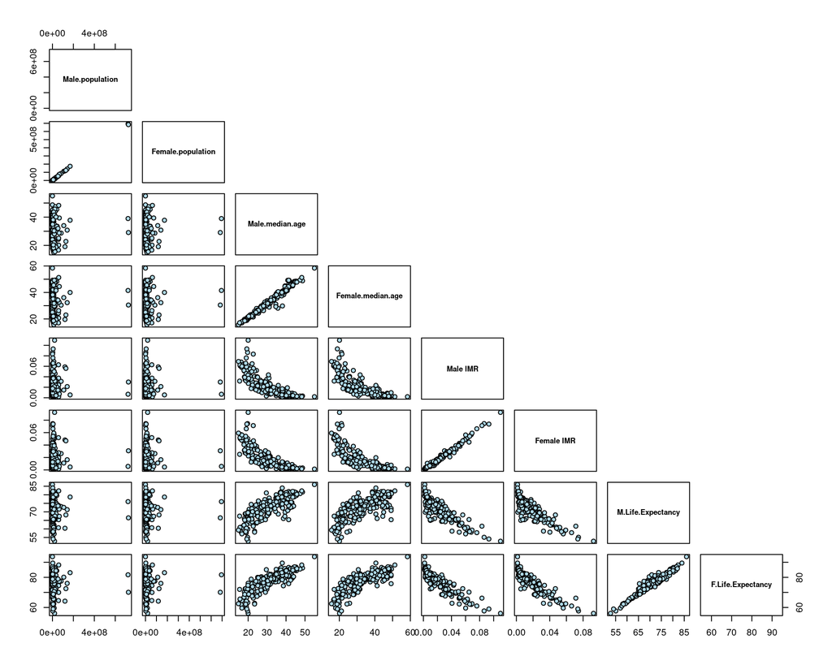

```r
pairs(gendered_df,
      labels = colnames(gendered_df),
      cex.labels = 0.8,            # label size
      font.labels = 2,             # bold
      gap = 1,                   # spacing between plots and labels
      upper.panel = NULL,
      pch = 21,
      bg = "lightblue")         # optional: simplify upper triangle
```

## Linear Regression of Life Expectancy

```r
female.lm <- lm(trim_df$Female.life.expectancy.at.birth ~ trim_df$Male.life.expectancy.at.birth)
male.lm <- lm(trim_df$Male.life.expectancy.at.birth ~ trim_df$Female.life.expectancy.at.birth)

summary(female.lm)
```

```
##
## Call:
## lm(formula = trim_df$Female.life.expectancy.at.birth ~ trim_df$Male.life.expectancy.at.birth)
##
## Residuals:
##     Min      1Q  Median      3Q     Max
## -3.6122 -1.2852 -0.2838  0.8014  5.9458
##
## Coefficients:
##                                       Estimate Std. Error t value Pr(>|t|)
## (Intercept)                            3.20671    1.34665   2.381   0.0182 *
## trim_df$Male.life.expectancy.at.birth  1.02468    0.01861  55.051   <2e-16 ***
## ---
## Signif. codes:  0 '***' 0.001 '**' 0.01 '*' 0.05 '.' 0.1 ' ' 1
##
## Residual standard error: 1.729 on 199 degrees of freedom
## Multiple R-squared:  0.9384, Adjusted R-squared:  0.9381
## F-statistic:  3031 on 1 and 199 DF,  p-value: < 2.2e-16
```

```r
summary(male.lm)
```

```
##
## Call:
## lm(formula = trim_df$Male.life.expectancy.at.birth ~ trim_df$Female.life.expectancy.at.birth)
##
## Residuals:
##     Min      1Q  Median      3Q     Max
## -5.5221 -0.7001  0.2640  1.0546  3.6252
##
## Coefficients:
##                                         Estimate Std. Error t value Pr(>|t|)
## (Intercept)                              1.50298    1.28668   1.168    0.244
## trim_df$Female.life.expectancy.at.birth  0.91578    0.01664  55.051   <2e-16
##
## (Intercept)
## trim_df$Female.life.expectancy.at.birth ***
## ---
## Signif. codes:  0 '***' 0.001 '**' 0.01 '*' 0.05 '.' 0.1 ' ' 1
##
## Residual standard error: 1.634 on 199 degrees of freedom
## Multiple R-squared:  0.9384, Adjusted R-squared:  0.9381
## F-statistic:  3031 on 1 and 199 DF,  p-value: < 2.2e-16
```

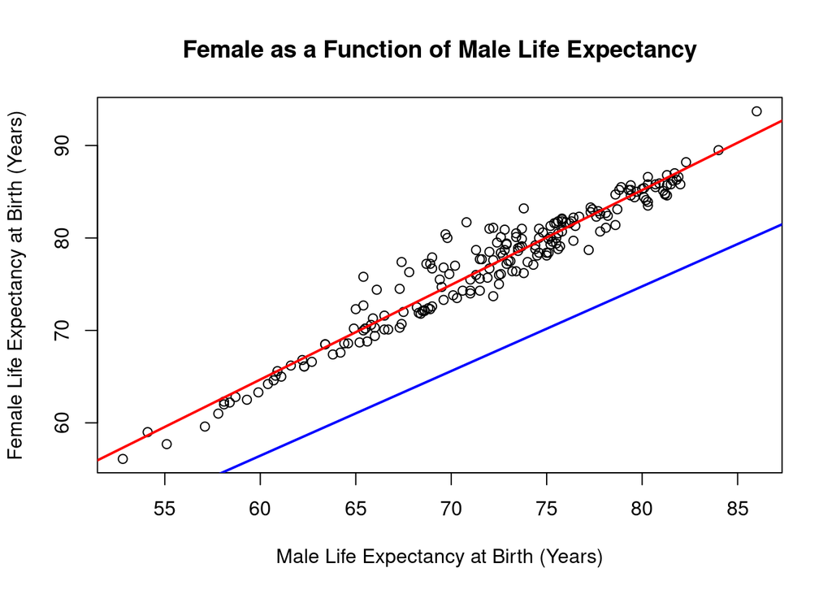

```r
plot(trim_df$Male.life.expectancy.at.birth, trim_df$Female.life.expectancy.at.birth, main="Female as a Function of Male Life Expectancy", xlab="Male Life Expectancy at Birth (Years)", ylab="Female Life Expectancy at Birth (Years)")
abline(female.lm, col="red", lwd=2)
abline(male.lm, col="blue", lwd=2)
```

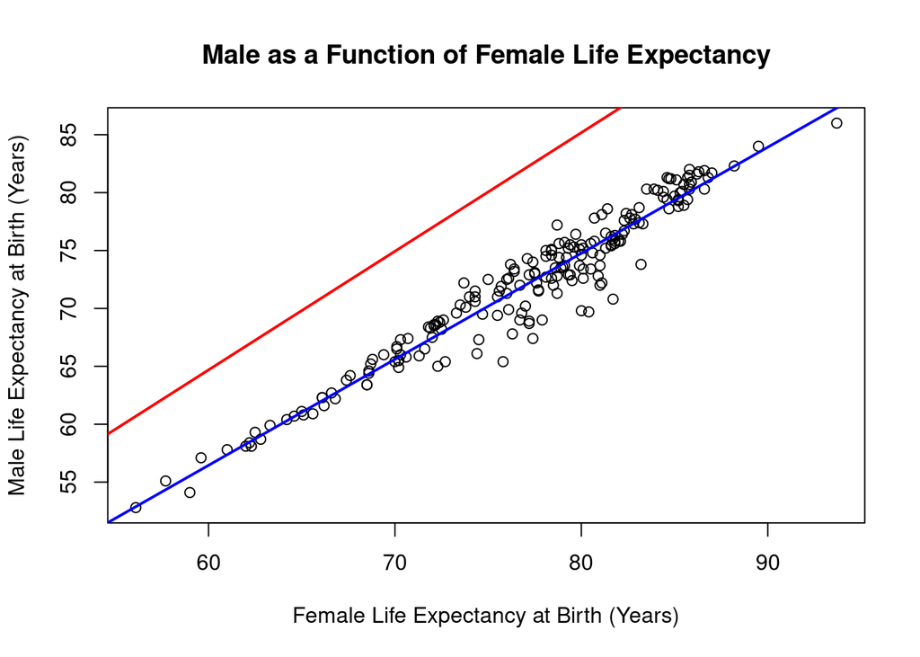

```r
plot(trim_df$Female.life.expectancy.at.birth, trim_df$Male.life.expectancy.at.birth, main="Male as a Function of Female Life Expectancy", ylab="Male Life Expectancy at Birth (Years)", xlab="Female Life Expectancy at Birth (Years)")
abline(female.lm, col="red", lwd=2)
abline(male.lm, col="blue", lwd=2)
```

From these two plots with regression lines, we can see that the female life expectancy has a larger intercept than the male life expectancy (approximately 1.5 years on average), meaning that on average, women live longer according to the data. The increase in slope could mean that in countries with a high life expectancy among both groups, the gap in life expectancy between men and women is larger Likewise, in countries with a lower life expectancy among both groups there is a smaller gap.

## Linear Regression of IMR (Deaths per Birth)

```r
female.lm <- lm(trim_df$Male.IMR.deaths.per.birth ~ trim_df$Female.IMR.deaths.per.birth)
male.lm <- lm(trim_df$Female.IMR.deaths.per.birth ~ trim_df$Male.IMR.deaths.per.birth)

summary(female.lm)
```

```
##
## Call:
## lm(formula = trim_df$Male.IMR.deaths.per.birth ~ trim_df$Female.IMR.deaths.per.birth)
##
## Residuals:
##        Min         1Q     Median         3Q        Max
## -0.0083493 -0.0008393 -0.0004242  0.0006309  0.0115811
##
## Coefficients:
##                                      Estimate Std. Error t value Pr(>|t|)
## (Intercept)                         0.0007052  0.0002454   2.874   0.0045 **
## trim_df$Female.IMR.deaths.per.birth 1.2054103  0.0100971 119.382   <2e-16 ***
## ---
## Signif. codes:  0 '***' 0.001 '**' 0.01 '*' 0.05 '.' 0.1 ' ' 1
##
## Residual standard error: 0.00239 on 199 degrees of freedom
## Multiple R-squared:  0.9862, Adjusted R-squared:  0.9862
## F-statistic: 1.425e+04 on 1 and 199 DF,  p-value: < 2.2e-16
```

```r
summary(male.lm)
```

```
##
## Call:
## lm(formula = trim_df$Female.IMR.deaths.per.birth ~ trim_df$Male.IMR.deaths.per.birth)
##
## Residuals:
##        Min         1Q     Median         3Q        Max
## -0.0094294 -0.0005479  0.0002247  0.0006255  0.0073618
##
## Coefficients:
##                                     Estimate Std. Error t value Pr(>|t|)
## (Intercept)                       -0.0003338  0.0002050  -1.628    0.105
## trim_df$Male.IMR.deaths.per.birth  0.8181691  0.0068534 119.382   <2e-16 ***
## ---
## Signif. codes:  0 '***' 0.001 '**' 0.01 '*' 0.05 '.' 0.1 ' ' 1
##
## Residual standard error: 0.001969 on 199 degrees of freedom
## Multiple R-squared:  0.9862, Adjusted R-squared:  0.9862
## F-statistic: 1.425e+04 on 1 and 199 DF,  p-value: < 2.2e-16
```

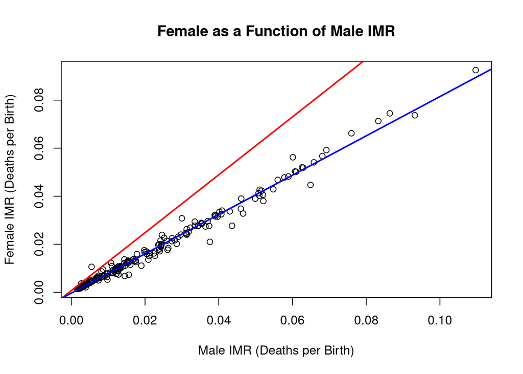

```r
plot(trim_df$Male.IMR.deaths.per.birth, trim_df$Female.IMR.deaths.per.birth, main="Female as a Function of Male IMR", xlab="Male IMR (Deaths per Birth)", ylab="Female IMR (Deaths per Birth)")
abline(female.lm, col="red", lwd=2)
abline(male.lm, col="blue", lwd=2)
```

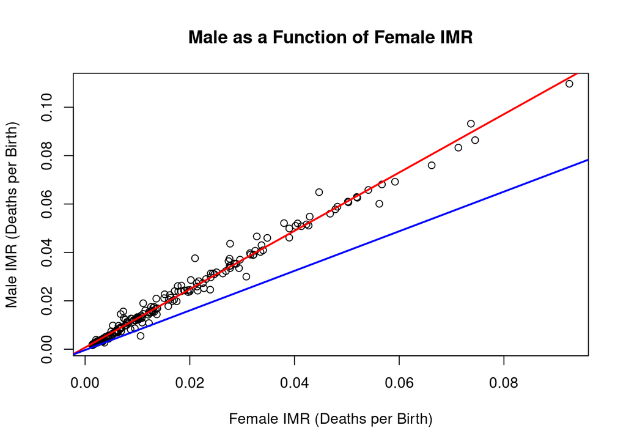

```r
plot(trim_df$Female.IMR.deaths.per.birth, trim_df$Male.IMR.deaths.per.birth, main="Male as a Function of Female IMR", ylab="Male IMR (Deaths per Birth)", xlab="Female IMR (Deaths per Birth)")
abline(female.lm, col="red", lwd=2)
abline(male.lm, col="blue", lwd=2)
```

# Maps

Function to plot an interactive map

```r
plot_country_data <- function(df, country_col, value_col, fill_color = "YlOrRd", legend_title = NULL) {
  df <- na.omit(df)
  # Step 1: Add ISO3 codes
  df$iso_a3 <- countrycode(df[[country_col]], "country.name", "iso3c")
  df$iso_a3[df[[country_col]] == "Kosovo"] <- "XKX"  # Manually fix Kosovo

  # Step 2: Get world map
  world <- ne_countries(returnclass = "sf")

  # Step 3: Join data onto world map
  joined <- left_join(world, df[, c("iso_a3", value_col)], by = "iso_a3")

  # Step 4: Set up color palette based on data
  pal <- colorNumeric(palette = fill_color, domain = df[[value_col]], na.color = "#cccccc")

  # Step 5: Make map
  leaflet(joined) %>%
    addTiles() %>%
    addPolygons(
      fillColor = ~pal(get(value_col)),  # Directly use get() for value_col
      color = "white",
      weight = 1,
      opacity = 1,
      fillOpacity = 0.8,
      label = ~paste(name, ": ", ifelse(is.na(get(value_col)), "NA", round(get(value_col), 2))),
      highlightOptions = highlightOptions(weight = 2, color = "#666", bringToFront = TRUE)
    ) %>%
    addLegend(
      pal = pal,
      values = df[[value_col]],
      title = legend_title %||% value_col,
      na.label = "No data"
    )
}
```

Plot the difference in expected years of education by country (female - male). Positive values indicate females attain more education on average.

```r
colnames(trim_df)
```

```
##  [1] "Male.population"
##  [2] "Female.population"
##  [3] "Median.age.male"
##  [4] "Median.age.female"
##  [5] "Male.IMR.deaths.per.birth"
##  [6] "Female.IMR.deaths.per.birth"
##  [7] "Male.life.expectancy.at.birth"
##  [8] "Female.life.expectancy.at.birth"
##  [9] "Male.proportion.of.tobacco.users"
## [10] "Female.proportion.of.tobacco.users"
## [11] "Male.literacy.rate"
## [12] "Female.literacy.rate"
## [13] "Male.expected.years.of.education"
## [14] "Female.expected.years.of.education"
## [15] "Male.unemployment.rate.15.24"
## [16] "Female.unemployment.rate.15.24"
## [17] "Continent"
## [18] "Geography..Geographic.coordinates"
## [19] "Real.GDP.per.capita.USD"
## [20] "Total.population"
## [21] "Live.births.per.1000.people"
## [22] "Maternal.deaths.per.100000.live.births"
## [23] "Infant.deaths.per.1000.live.births"
## [24] "Life.expectancy.at.birth"
## [25] "Population.growth.rate.percent"
## [26] "Country"
## [27] "Diff.Expected.YOE"
## [28] "Diff.Literacy.Rate"
## [29] "Diff.Life.Expectancy"
```

```r
yoe_df <- trim_df[,c("Country", "Diff.Expected.YOE")]
#yoe_df

plot_country_data(yoe_df, "Country", "Diff.Expected.YOE", legend_title = "Expected Difference in Education")
```

[interactive chart not shown]

```r
dlr_df <- trim_df[,c("Country", "Diff.Literacy.Rate")]

plot_country_data(dlr_df, "Country", "Diff.Literacy.Rate", legend_title = "Expected Difference in Literacy Rate")
```

[interactive chart not shown]

# Other Vars!

Difference in life expectancy (female - male)

```r
dle_df <- trim_df[,c("Country", "Diff.Life.Expectancy")]

plot_country_data(dle_df, "Country", "Diff.Life.Expectancy", legend_title = "Expected Difference in Life Expectancy")
```

[interactive chart not shown]

The difference in life expectancy is large in the currently warring nations of Russia, Belarus, and Ukraine, presumably because the men are being sent to fight.

In the non-warring nations, we tend to see a less exaggerated but still positive difference in female and male life expectancy. That is, on average, females still tend to live longer on average.